# Notebook 22 – Solutions

## Getting Started

Before running this notebook, select “Session > Restart R and Clear Output” in the menu above to start a new R session. This will clear any old data sets and give us a blank slate to start with.

## Chicago Data

### Load the Data

```r
comarea <- read_sf(file.path("data", "chicago_community_areas.geojson"))
ziparea <- read_sf(file.path("data", "zip_codes.geojson"))
socio <- read_csv(file.path("data", "census_socioeconomic.csv"))
medical <- read_csv(file.path("data", "chicago_medical_examiner_cases.csv.gz"))
```

This time, we will look into the temporal components of the data and see how they can be integrated into the spatial visualisations.

## Practice

### Time of Day: Opioid Related

Repeate the code, but show the number of incidents (rather than deaths) that occur at each hour of the day, by whether the incident was opioid related or not.

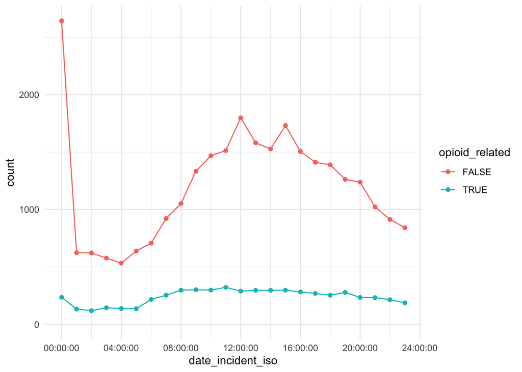

```r
medical %>%
  mutate(date_incident_iso = floor_date(date_incident_iso, "hour")) %>%
  mutate(date_incident_iso = as_hms(date_incident_iso)) %>%
  group_by(date_incident_iso, opioid_related) %>%
  summarize(sm_count()) %>%
  ggplot(aes(date_incident_iso, count)) +
    geom_point(aes(color = opioid_related)) +
    geom_line(aes(color = opioid_related)) +
    scale_y_continuous(limits = c(0, NA))
```

Do you notice anything strange? What percentage of non-opioid related deaths have an incident recorded exactly at midnight?

```r
medical %>%
  mutate(hour = hour(date_incident_iso), minute = minute(date_incident_iso)) %>%
  filter(!opioid_related) %>%
  summarize(mean((hour == 0) &  (minute == 0)))
```

```
## # A tibble: 1 × 1
##   `mean((hour == 0) & (minute == 0))`
##                                 <dbl>
## 1                              0.0695
```

Does there seem to be a data issue here?

### Time to Death

Compute the time between the recorded death and the recorded incident. Order the data with the longest duration at the top. Do you see anything strange? Is there a data issue here?

```r
medical %>%
  mutate(diff_time = as.numeric(date_death_iso - date_incident_iso)) %>%
  arrange(desc(diff_time))
```

```
## # A tibble: 34,566 × 15
##    date_incident_iso   date_death_iso      primary_cause     age gender race
##    <dttm>              <dttm>              <chr>           <dbl> <chr>  <chr>
##  1 1948-05-25 04:00:00 2016-08-01 10:59:00 COMPLICATIONS …    74 Male   Black
##  2 1973-07-23 00:00:00 2017-07-13 20:04:00 COMPLICATIONS …    68 Male   White
##  3 1983-02-10 00:00:00 2017-12-22 16:51:00 COMPLICATIONS …    66 Male   White
##  4 1989-01-01 13:00:00 2019-07-31 15:06:00 COMPLICATIONS …    48 Male   White
##  5 1989-05-05 00:00:00 2019-09-11 15:55:00 COMPLICATIONS …    59 Female Black
##  6 1985-01-28 00:00:00 2015-05-30 01:50:00 COMPLICATIONS …    32 Female Black
##  7 1988-07-14 15:45:00 2017-09-05 18:53:00 COMPLICATIONS …    66 Male   White
##  8 1986-12-27 01:30:00 2015-08-12 18:19:00 COMPLICATIONS …    76 Male   White
##  9 1992-02-01 00:00:00 2020-06-29 11:34:00 ASPIRATION PNE…    58 Male   White
## 10 1991-05-10 18:00:00 2017-03-30 11:58:00 ATHEROSCLEROTI…    40 Male   Black
## # … with 34,556 more rows, and 9 more variables: latino <lgl>,
## #   gun_related <lgl>, opioid_related <lgl>, cold_related <lgl>,
## #   heat_related <lgl>, lon <dbl>, lat <dbl>, residence_zip <chr>,
## #   diff_time <dbl>
```

I want you to investiage the median duration between the time of death and the time of the incident within the top-100 most common `primary_cause` labels. Create a table with the median time for each of the top-100 categories and arrange the table from the shortest to the longest duration

```r
medical %>%
  mutate(diff_time = as_hms(as.numeric(date_death_iso - date_incident_iso))) %>%
  group_by(primary_cause) %>%
  summarize(sm_count(), sm_median(diff_time)) %>%
  arrange(desc(count)) %>%
  slice(1:100) %>%
  select(primary_cause, diff_time_median) %>%
  arrange(diff_time_median)
```

```
## # A tibble: 100 × 2
##    primary_cause                   diff_time_median
##    <chr>                           <time>
##  1 CHRONIC ALCOHOLISM              17'00"
##  2 DILATED CARDIOMYOPATHY          19'30"
##  3 HANGING                         20'00"
##  4 ORGANIC  CARDIOVASCULAR DISEASE 20'00"
##  5 HEROIN AND FENTANYL TOXICITY    20'00"
##  6 MULTIPLE STAB WOUNDS            21'00"
##  7 CHRONIC ETHANOLISM              21'30"
##  8 INTRAORAL GUNSHOT WOUND         22'00"
##  9 ORGANIC CARDIOVASCUALR DISEASE. 22'30"
## 10 ORGANIC CARDIOVASCULAR DISEASE  23'00"
## # … with 90 more rows
```

Note: If you have the difference in time in seconds, try using the function `as_hms` to convert these integers into hours, minutes, and seconds. Do the results seem reasonable to you? Any strange outliers?

### Heat and Cold Deaths

Create a plot with hour on the x-axis and month on the y-axis. Show a scatter plot with points showing the total number of cold-related deaths that occured (incident time, not time of death) at each combination of hour of the day and month. Try to make the plot look nice (no need for fancy labels, but maybe make sure to include real month names and properly formatted dates).

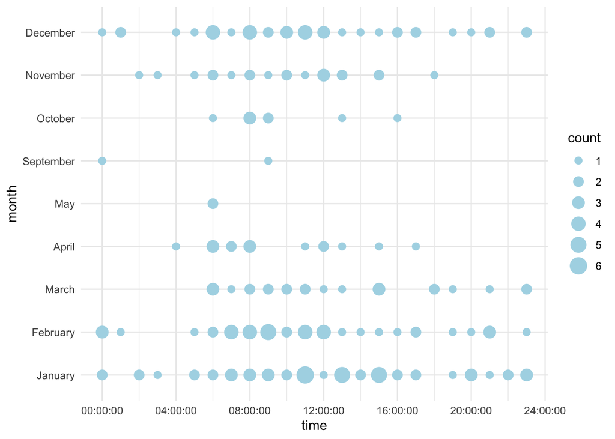

```r
medical %>%
  filter(cold_related) %>%
  mutate(
    time = as_hms(floor_date(date_incident_iso, "hour")),
    month = month(date_incident_iso, label = TRUE, abbr = FALSE)
  ) %>%
  group_by(month, time) %>%
  summarize(sm_count()) %>%
  ggplot(aes(time, month)) +
    geom_point(aes(size = count), color = "#add8e6") +
    scale_size_area()
```

Repeat the previous question, but look at heat related deaths.

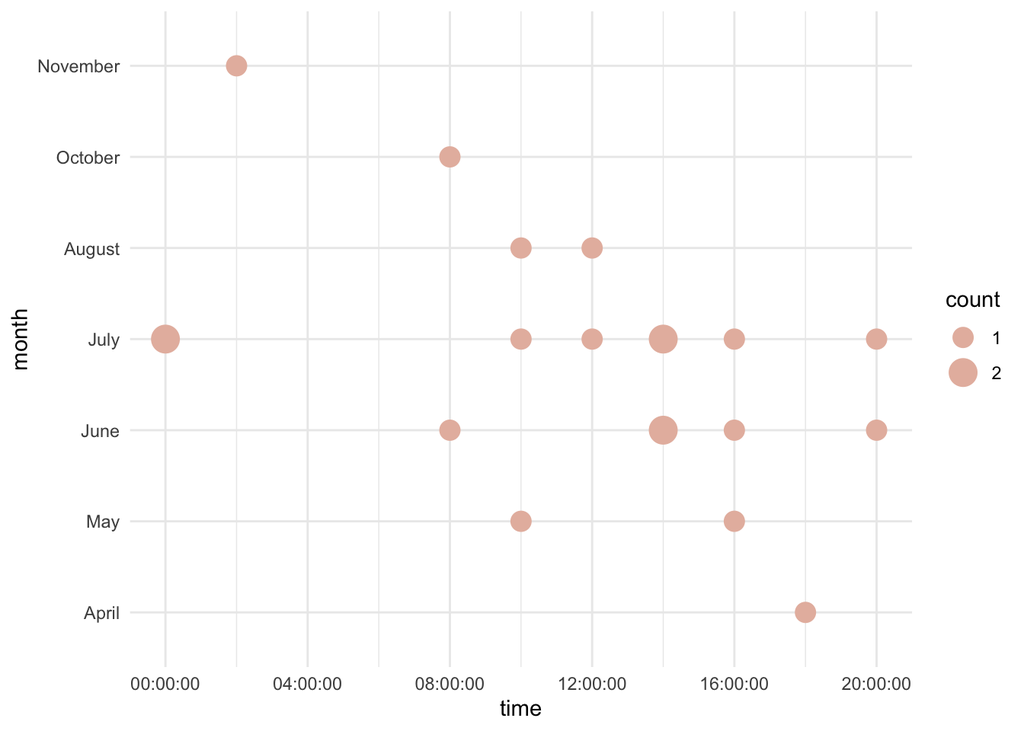

```r
medical %>%
  filter(heat_related) %>%
  mutate(
    time = as_hms(floor_date(date_incident_iso, "2 hour")),
    month = month(date_incident_iso, label = TRUE, abbr = FALSE)
  ) %>%
  group_by(month, time) %>%
  summarize(sm_count()) %>%
  ggplot(aes(time, month)) +
    geom_point(aes(size = count), color = "#e6bbad") +
    scale_size_area(breaks = c(1, 2))
```

Do the patterns surprise you at all?

### Time of the Week

In this final question, I want you to show the number of deaths on the y-axis as a function of the hour of the week (hour 0 is Monday at midnight, hour 24 is Tuesday at midnight, etc). It will take a little bit of work to get this correct, particularly if you want to axes to be labelled correctly without resorting to hand labels.

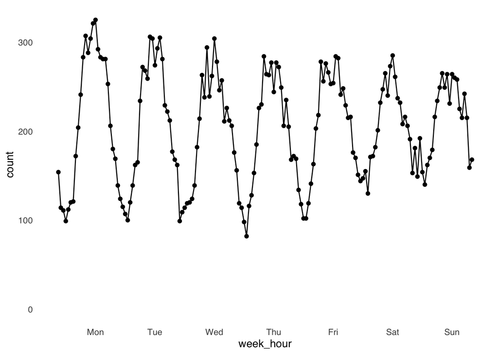

```r
medical %>%
  mutate(death_hour = floor_date(date_death_iso, "hour")) %>%
  mutate(diff = death_hour - floor_date(death_hour, "week")) %>%
  mutate(week_hour = make_datetime(2020, 11, 2) + diff) %>%
  group_by(week_hour) %>%
  summarize(sm_count()) %>%
  ggplot(aes(week_hour, count)) +
    geom_point() +
    geom_line() +
    scale_x_datetime(
      date_breaks = "24 hours",
      date_minor_breaks = "24 hours",
      date_labels = "%a"
    ) +
    scale_y_continuous(limits = c(0, NA)) +
    theme_sm()
```